# index

# Q1.

#### Take a moment to reflect on the value of open data:

How does easy access to historical and real-time environmental data shape our understanding of climate trends, resource management, and public health? What happens when this data disappears or becomes inaccessible? The role of independent archiving and collaborative stewardship has never been more critical in ensuring scientific progress and accountability.

1. When we can access historical and real-time data, we’re better able to draw connections between previous conditions and the present to identify trends over time. We can see how present observations fit with previous data, which is the most important evidence that climate change is happening. When these data are accessible to everyone, we can hold our leaders accountable for the decisions they make, which are supposed to be on behalf of the public. Natural resource management is a very rough science that can be heavily influenced by policies, so access to data over time is crucial for holding agencies accountable in processes like the National Environmental Policy Act, where the public has a chance to influence agency actions, or the actions of any major actor on natural resources, or to identify trends over time that have multiple influences. When the data disappear or become inaccessible, people can get away with lying to support ulterior motives and decision makers can make choices with catastrophic consequences.

# Q2.Daily Summary

# Conditions to Meet for CO Public Health

For **More than 100 new cases in Colorado per 100,000 residents over the past 14 days**, report also:

1. cumulative cases in the 5 worst counties
2. total NEW cases in the 5 worst counties
3. A list of safe counties
4. A text report describing the total new cases,
5. total cumulative cases, and number of safe counties.

### Steps Q2

1. Start by reading in the data from the NY-Times URL with read_csv (make sure to attach the tidyverse)

```r
library(dplyr)
library(tidyverse)
library(flextable)
library(zoo)
data = read_csv('https://raw.githubusercontent.com/nytimes/covid-19-data/master/us-counties.csv')
```

2. Create an object called my.date and set it as “2022-02-01” - ensure this is a date object:. Create a object called my.state and set it to “Colorado”.

```r
txt <- "2022-02-01"
class(txt)
```

```
[1] "character"
```

```r
my.date <- as.Date(txt)
class(my.date)
```

```
[1] "Date"
```

```r
my.state <- as.character("Colorado")
class(my.state)
```

```
[1] "character"
```

3.The URL based data read from Github is considered our “raw data”. Remember to always leave “raw-data-raw” and to generate meaningful subsets as you go.

Start by making a subset that limits (filter) the data to Colorado and add a new column (mutate) with the daily new cases using diff/lag by county (group_by). Do the same for new deaths as well.

```r
library(knitr)

co_covid <- data %>%
  filter(state == "Colorado") %>%
  group_by(county) %>%
  mutate(case_lag = lag(cases, n = 1)) %>%
  mutate(new_cases = cases-case_lag) %>%
  mutate(death_lag = lag(deaths, n = 1)) %>%
  mutate(new_deaths = deaths - death_lag) %>%
  arrange(date) %>%
  ungroup()
```

Q2. Using your subset, generate (2) tables. The first should show the 5 counties with the most CUMULATIVE cases, and the second should show the 5 counties with the most NEW cases. Remember to use your my.date object as a proxy for today’s date:

### Colorado: Top 5 counties with the most cumulative cass

```r
#five counties with the most cumulative cases

co_covid %>%
   filter(date == my.date) %>%
  select(county, cases) %>%
  slice_max(order_by = cases, n = 5) %>%
  kable(caption = "Five Colorado counties with the most cumulative COVID cases as of February 1st, 2022")
```

Five Colorado counties with the most cumulative COVID cases as of February 1st, 2022

| county | cases |
| --- | --- |
| El Paso | 170673 |
| Denver | 159022 |
| Arapahoe | 144255 |
| Adams | 126768 |
| Jefferson | 113240 |

### Colorado: top 5 counties with the most new cases

```r
#five counties with the most new cases

co_covid %>%
  filter(date == my.date) %>%
  select(county, new_cases) %>%
  slice_max(order_by = new_cases, n = 5, na_rm = TRUE) %>% kable(caption = "Five Colorado counties with the most new COVID cases on Febrary 1st, 2022")
```

Five Colorado counties with the most new COVID cases on Febrary 1st, 2022

| county | new_cases |
| --- | --- |
| El Paso | 630 |
| Arapahoe | 401 |
| Denver | 389 |
| Adams | 326 |
| Jefferson | 291 |

Your tables should have clear column names and descriptive captions.

# Q3: Normalizing Data

Raw count data can be deceiving given the wide range of populations in Colorado countries. To help us normalize data counts, we need supplemental population data to be added. Population data is offered by the Census and can be found here. Please read in this data.

How FIPS codes are structured - The number of digits in a FIPS code depends on the level of geography - State FIPS codes have two digits - County FIPS codes have five digits, with the first two digits representing the state FIPS code

1. Convert the STATE numeric into a character forced to 2 digits with a leading 0 (when needed)
2. Convert the COUNTY numeric into a character forced to 3 digits with leading 0’s (when needed)
3. Create a FIP variable the STATE numeric into a character forced to 2 digits with a leading 0 (when needed)

```r
pop_url <- 'https://www2.census.gov/programs-surveys/popest/datasets/2020-2023/counties/totals/co-est2023-alldata.csv'

pop = read_csv(pop_url)
# In this part, we're adding the correct amount of digits to each component of the fips data, which in this table was separated. We want to merge the state and county column to get a complete county fip, which will be the overlapping we make our join table off of

pop <- pop |>
  mutate(STATE = as.numeric(STATE), COUNTY = as.numeric(COUNTY))|>
  mutate(fips = paste0(sprintf("%02d",STATE),sprintf("%03d", COUNTY)))
```

1. Given the above URL, and guidelines on string concatenation and formatting, read in the population data and (1) create a five digit FIP variable and only keep columns that contain “NAME” or “2021” (remember the tidyselect option found with ?dplyr::select). Additionally, remove all state level rows (e.g. COUNTY FIP == “000”)

1

```r
library(stringr)

pop21 <- pop %>%
  select(fips, contains("2021"), contains("NAME")) %>%
filter(!str_ends(fips, "000"))
```

2. Now, explore the data … what attributes does it have, what are the names of the columns? Do any match the COVID data we have? What are the dimensions… In a few sentences describe the data obtained after modification:

```r
names(pop21)
```

```
 [1] "fips"                  "POPESTIMATE2021"       "NPOPCHG2021"
 [4] "BIRTHS2021"            "DEATHS2021"            "NATURALCHG2021"
 [7] "INTERNATIONALMIG2021"  "DOMESTICMIG2021"       "NETMIG2021"
[10] "RESIDUAL2021"          "GQESTIMATES2021"       "RBIRTH2021"
[13] "RDEATH2021"            "RNATURALCHG2021"       "RINTERNATIONALMIG2021"
[16] "RDOMESTICMIG2021"      "RNETMIG2021"           "STNAME"
[19] "CTYNAME"
```

```r
dim(pop21)
```

```
[1] 3144   19
```

```r
nrow(pop21)
```

```
[1] 3144
```

```r
str(pop21)
```

```
tibble [3,144 × 19] (S3: tbl_df/tbl/data.frame)
 $ fips                 : chr [1:3144] "01001" "01003" "01005" "01007" ...
 $ POPESTIMATE2021      : num [1:3144] 59203 239439 24533 22359 59079 ...
 $ NPOPCHG2021          : num [1:3144] 288 6212 -436 171 -28 ...
 $ BIRTHS2021           : num [1:3144] 686 2337 270 240 654 ...
 $ DEATHS2021           : num [1:3144] 696 2948 390 325 875 ...
 $ NATURALCHG2021       : num [1:3144] -10 -611 -120 -85 -221 -49 -70 -593 -200 -188 ...
 $ INTERNATIONALMIG2021 : num [1:3144] 15 105 0 1 9 1 5 12 22 7 ...
 $ DOMESTICMIG2021      : num [1:3144] 242 6972 -313 254 141 ...
 $ NETMIG2021           : num [1:3144] 257 7077 -313 255 150 ...
 $ RESIDUAL2021         : num [1:3144] 41 -254 -3 1 43 4 5 86 21 2 ...
 $ GQESTIMATES2021      : num [1:3144] 484 3351 2248 1994 616 ...
 $ RBIRTH2021           : num [1:3144] 11.62 9.89 10.91 10.78 11.07 ...
 $ RDEATH2021           : num [1:3144] 11.8 12.5 15.8 14.6 14.8 ...
 $ RNATURALCHG2021      : num [1:3144] -0.169 -2.585 -4.848 -3.816 -3.74 ...
 $ RINTERNATIONALMIG2021: num [1:3144] 0.254 0.4443 0 0.0449 0.1523 ...
 $ RDOMESTICMIG2021     : num [1:3144] 4.1 29.5 -12.65 11.4 2.39 ...
 $ RNETMIG2021          : num [1:3144] 4.35 29.95 -12.65 11.45 2.54 ...
 $ STNAME               : chr [1:3144] "Alabama" "Alabama" "Alabama" "Alabama" ...
 $ CTYNAME              : chr [1:3144] "Autauga County" "Baldwin County" "Barbour County" "Bibb County" ...
```

```r
glimpse(pop21)
```

```
Rows: 3,144
Columns: 19
$ fips                  <chr> "01001", "01003", "01005", "01007", "01009", "01…
$ POPESTIMATE2021       <dbl> 59203, 239439, 24533, 22359, 59079, 10143, 18890…
$ NPOPCHG2021           <dbl> 288, 6212, -436, 171, -28, -86, -135, -565, -163…
$ BIRTHS2021            <dbl> 686, 2337, 270, 240, 654, 111, 227, 1250, 392, 2…
$ DEATHS2021            <dbl> 696, 2948, 390, 325, 875, 160, 297, 1843, 592, 4…
$ NATURALCHG2021        <dbl> -10, -611, -120, -85, -221, -49, -70, -593, -200…
$ INTERNATIONALMIG2021  <dbl> 15, 105, 0, 1, 9, 1, 5, 12, 22, 7, 20, 1, 0, -1,…
$ DOMESTICMIG2021       <dbl> 242, 6972, -313, 254, 141, -42, -75, -70, -6, 28…
$ NETMIG2021            <dbl> 257, 7077, -313, 255, 150, -41, -70, -58, 16, 29…
$ RESIDUAL2021          <dbl> 41, -254, -3, 1, 43, 4, 5, 86, 21, 2, 18, 7, 8, …
$ GQESTIMATES2021       <dbl> 484, 3351, 2248, 1994, 616, 1578, 285, 5407, 856…
$ RBIRTH2021            <dbl> 11.615503, 9.888589, 10.908650, 10.775136, 11.06…
$ RDEATH2021            <dbl> 11.78483, 12.47392, 15.75694, 14.59133, 14.80717…
$ RNATURALCHG2021       <dbl> -0.1693222, -2.5853351, -4.8482890, -3.8161941, …
$ RINTERNATIONALMIG2021 <dbl> 0.25398330, 0.44428836, 0.00000000, 0.04489640, …
$ RDOMESTICMIG2021      <dbl> 4.0975973, 29.5007468, -12.6459537, 11.4036860, …
$ RNETMIG2021           <dbl> 4.3515806, 29.9450352, -12.6459537, 11.4485824, …
$ STNAME                <chr> "Alabama", "Alabama", "Alabama", "Alabama", "Ala…
$ CTYNAME               <chr> "Autauga County", "Baldwin County", "Barbour Cou…
```

```r
#my computer can't do skimr()

intersect(names(pop21), names(co_covid))
```

```
[1] "fips"
```

2. There are 3144 rows and 19 columns in pop21. There are demographic data like births, deaths, and migration. As of right now, the only columns that intersect are fips because I created that column in the population dataset. Both datasets have county names, state names. While pop21 has total deaths, co_covid just has COVID deaths.What I’m trying to figure out is how a join will happen if the number of rows for my population and covid data don’t match up. I found out that whatever dataset you specify for the join is the number of columns the function will output.

3 What is the range of populations seen in Colorado counties in 2021:

```r
COpop21 <- pop21 %>%
filter(STNAME == "Colorado") %>%  mutate(state = STNAME, county = CTYNAME) %>%
  select(-CTYNAME, -STNAME) %>%
  mutate(county = str_replace(county, " County", ""))

range(COpop21$POPESTIMATE2021)
```

```
[1]    741 737287
```

3. In Colorado, county populations range from 741 to 737287.
4. Join the population data to the Colorado COVID data and compute the per capita cumulative cases, per capita new cases, and per capita new deaths:

```r
co_covid <- co_covid %>%
  arrange(county)

co_covid_pop <- left_join(co_covid, COpop21, by = NULL) %>%
  group_by(county) %>%
  mutate(percap_cumulative = cases/POPESTIMATE2021) %>%
  mutate(percap_new_cases = new_cases/POPESTIMATE2021) %>%
  mutate(percap_new_deaths = new_deaths/POPESTIMATE2021) %>%
ungroup()
```

5. Generate (2) new tables. The first should show the 5 counties with the most cumulative cases per capita on 2021-01-01, and the second should show the 5 counties with the most NEW cases per capita on the same date. Your tables should have clear column names and descriptive captions.

#### First Table

```r
co_covid_pop %>%
  mutate(date_char = as.character(date)) %>%
select(percap_cumulative, county, date_char, cases) %>%
  group_by(date_char) %>%
  arrange(date_char) %>%
  filter(date_char == "2021-01-01")  %>% slice_max(order_by = percap_cumulative, n = 5) %>%
  flextable(col_keys = c("percap_cumulative", "cases", "county")) %>%  #
  width(width = 0.75) %>%
  height(height = 0.25) %>%
  set_header_labels(
    cases = "Cumulative Cases",
    percap_cumulative = "Cases per Capita",
    county = "County"
  ) %>%
   set_caption("Top 5 Counties by Cumulative COVID Cases per Capita on Jan 1, 2021") %>%
  theme_booktabs()
```

| Cases per Capita | Cumulative Cases | County |
| --- | --- | --- |
| 0.28945074 | 1,660 | Crowley |
| 0.21090092 | 1,126 | Bent |
| 0.15467009 | 3,249 | Logan |
| 0.14306596 | 783 | Lincoln |
| 0.09507078 | 4,681 | Fremont |

#### Second Table

```r
co_covid_pop %>%
  mutate(date_char = as.character(date)) %>%
select(percap_new_cases, county, date_char, new_cases, cases) %>%
  group_by(date_char) %>%
  arrange(date_char) %>%
  filter(date_char == "2021-01-01")  %>% slice_max(order_by = percap_new_cases, n = 5) %>%
ungroup() %>%
  flextable(col_keys = c("percap_new_cases", "new_cases", "county")) %>%
  width(width = 0.75) %>%
  height(height = 0.25) %>%
  set_header_labels(
    percap_new_cases = "New Cases per Capita",
    new_cases = "New Cases",
    county = "County"
  ) %>%
   set_caption("Top 5 Counties by New COVID Cases per Capita on Jan 1, 2021") %>%
  theme_booktabs()
```

| New Cases per Capita | New Cases | County |
| --- | --- | --- |
| 0.016669788 | 89 | Bent |
| 0.003439381 | 8 | Sedgwick |
| 0.002634112 | 52 | Chaffee |
| 0.002266783 | 13 | Crowley |
| 0.002152853 | 2 | Mineral |

#Q4. Rolling Thresholds National

A rolling threshold is a predefined value that changes as time advances.

Filter the merged COVID/Population data to **only include the last 14 days**. Remember this should be a programmatic request and not hard-coded. Then, use the group_by/summarize paradigm to determine the total number of new cases in the last 14 days per 100,000 people. Print a table of the top 5 counties, and, report the number that meet the watch list condition: “More than 100 new cases per 100,000 residents over the past 14 days…”

### Total number of new cases, last 14 days for each county

```r
data <- data %>%
arrange(county, date)

# finding the new cases nationally
data <- data %>%
arrange(state, county, date) %>%
  group_by(county) %>%
  mutate(case_lag = lag(cases, n = 1, order_by = county)) %>%
  mutate(death_lag = lag(deaths, n = 1, order_by = county)) %>%
  mutate(new_cases = cases-case_lag) %>%
  mutate(new_deaths = deaths - death_lag) %>%
  ungroup()

#changing population, state, and county column data to overlap with covid data for a join
pop <- pop %>%
  select(fips, contains("202"), contains("NAME")) %>%
filter(!str_ends(fips, "000")) %>%
mutate(state = STNAME, county = CTYNAME) %>%
  select(-CTYNAME, -STNAME) %>%
  mutate(county = str_replace(county, " County", ""))

#covid-population join
covid_pop <- left_join(data, pop, by = NULL)
#COVID/Population data to only include the last 14 days for 100k people

last_14_per100k <- covid_pop %>%
  filter(date >= (max(date)-14)) %>%
  group_by(fips, date) %>%
  mutate(new_perpop = new_cases/POPESTIMATE2021) %>%
  group_by(fips) %>%
  summarize(new_casesper100k = sum(new_perpop)*1e5, cumulative_cases = max(cases), county = first(county), state = first(state), na.rm = TRUE) %>%
ungroup()
```

###National Top 5 Counties with highest new case count in the last 14 days and number of counties meeting watchlist conditions

```r
#top 5 counties

last_14_per100k %>%
  slice_max(new_casesper100k, n = 5) %>%
  flextable()
```

| fips | new_casesper100k | cumulative_cases | county | state | na.rm |
| --- | --- | --- | --- | --- | --- |
| 48301 | 18,518.519 | 196 | Loving | Texas | TRUE |
| 29089 | 3,430.261 | 2,515 | Howard | Missouri | TRUE |
| 29071 | 3,016.893 | 25,852 | Franklin | Missouri | TRUE |
| 55078 | 2,024.668 | 1,987 | Menominee | Wisconsin | TRUE |
| 02230 | 1,743.679 | 187 | Skagway Municipality | Alaska | TRUE |

```r
#number of counties meeting the watch list condition

last_14_per100k %>%
  filter(new_casesper100k > 100) %>% nrow()
```

```
[1] 1773
```

1773 counties in the United States meet the watchlist condition of greater than 100 cases per 100k residents in the last 14 days.

# Q5: Death Toll

Given we are assuming it is February 1st, 2022. Your leadership has asked you to determine what percentage of deaths in each county were attributed to COVID last year (2021). You eagerly tell them that with the current Census data, you can do this!

From previous questions you should have a data.frame with daily COVID deaths in Colorado and the Census based, 2021 total deaths. For this question, you will find the ratio of total COVID deaths per county (2021) of all recorded deaths. In a plot of your choosing, visualize all counties where COVID deaths account for 20% or more of the annual death toll.

```r
# Percentage of deaths that were due to COVID in 2021 for each county will require the population data and the covid cases data. We're going to use CO_Covid_pop for this and filter the year to 2021.
#Variables:
#DEATHS2021
#deaths

#create an object that represents deaths from just the year 2021


co_covid_pop <- co_covid_pop %>%
  mutate(year = lubridate::year(date))


deaths_2021 <- co_covid_pop %>%
  group_by(county) %>%
  filter(date == "2021-12-31") %>%
  mutate(deaths_2021 = deaths) %>%
  select(deaths_2021, county)

deaths_2020 <- co_covid_pop %>%
  group_by(county) %>%
  filter(date == "2020-12-31") %>%
  mutate(deaths_2020 = deaths) %>%
  select(deaths_2020, county)

cov_death_2021 <- co_covid_pop %>%
  select(DEATHS2021, county, date) %>%
  filter(date == "2021-12-31") %>%
  group_by(county) %>%
  right_join(deaths_2020) %>%
  right_join(deaths_2021) %>%
  group_by(county) %>%
  mutate(deaths_2021_only = deaths_2021-deaths_2020) %>%
  mutate(cov_death_percent = (deaths_2021_only/DEATHS2021)*100) %>%
  select(deaths_2021_only, cov_death_percent) %>%  filter(cov_death_percent >= 20)
```

### Making the graph

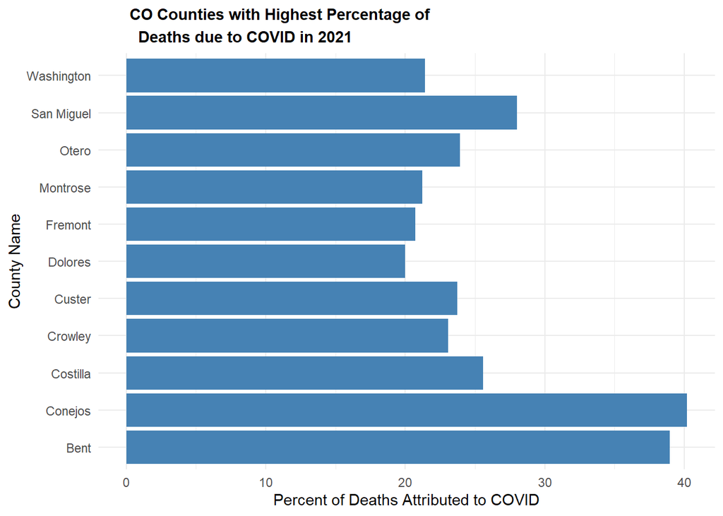

```r
ggplot(data = cov_death_2021,
       aes(x = county, y = cov_death_percent)) +
       geom_bar(stat = "Identity", fill = "steelblue") +
  coord_flip() +
  theme_minimal()+
  labs(
    x = "County Name",
    y = "Percent of Deaths Attributed to COVID",
    title = "CO Counties with Highest Percentage of\nDeaths due to COVID in 2021"
  ) +
  theme (plot.title = element_text(size = 11, hjust = .1, lineheight = 1.2, face = "bold"))
```

# Q6: Multi-state

In this question, we are going to look at the story of 4 states and the impact scale can have on data interpretation. The states include: New York, Colorado, Alabama, and Ohio. Your task is to make a faceted bar plot showing the number of daily, new cases at the state level.

1. First, we need to group/summarize our county level data to the state level, filter it to the four states of interest, and calculate the number of daily new cases (diff/lag) and the 7-day rolling mean.

```r
covid_state <- data %>%
  group_by(date, state) %>%
  summarize(cases = sum(cases)) %>% #this makes each state have a cumulative case count for each day instead of separating it by county
  filter(state %in% c("New York", "Colorado", "Alabama", "Ohio")) %>% #new cases grouped together by state
  group_by(state) %>% #had to group by state again because we just summarized
  mutate(new_cases = cases - lag(cases)) %>%
  mutate(roll = zoo::rollmean(new_cases, k = 7, align = "right", fill = NA, na.rm = TRUE)) %>%
    #k is the size being averaged, align is where those values are relative to the reference, fill is for the beginning and end of the dataset, where there are no additional numbers to average
  ungroup()
  #makes a data.frame with new cases for each day in the whole state#ensures grouping by state continues in this dataframe
```

2. Using the modified data, make a facet plot of the daily new cases and the 7-day rolling mean. Your plot should use compelling geoms, labels, colors, and themes.

[figure not shown]

```r
ggplot(covid_state, aes(x = date), na.rm = TRUE) +
geom_col(aes(y = new_cases), fill = "pink", col = NA) +#adds bar charts to represent the daily new COVID-19 cases. The height of each bar is determined by the newCases variable. The bars are filled with pink, and col = NA removes any border color from the bars.
 geom_line(aes(y = roll), col = "darkred", linewidth = 1) + # Overlays a line plot on the bars, representing the 7-day rolling average of new cases. The line is colored dark red and has a width of 1 for better visibility.
  theme_linedraw() + #applies a clean, simple theme with black axis lines and minimal distractions.
  facet_wrap(~state, nrow = 2, scales = "fixed") + # creates separate plots for each state using facet wrapping.    The nrow = 2 argument arranges the plots in two rows. The scales = "free_y" setting allows each state's y-axis to be independently scaled, preventing small-case states from being overshadowed by larger-case states
ggtitle("Cumulative COVID-19 Cases") + xlab("Date") +
  ylab("Case Count") + # adds a title and labels for the x and y axes. The title describes the plot, while the x-axis represents the date, and the y-axis represents the number of cases
   theme (plot.title = element_text(size = 11, hjust = .5, lineheight = 1.2, face = "bold"), axis.text.x = element_text(angle = 45, hjust = 1, size = 7), axis.text.y = element_text(hjust = 1, size = 7))
```

```r
# In R, when adding layers or components to a plot, each + should be on the same line as the previous part of the plot, not as a new statement.
```

3. The story of raw case counts can be misleading. To understand why, lets explore the cases per capita of each state. To do this, join the state COVID data to the population estimates and calculate the new cases/ total population. Additionally, calculate the 7-day rolling mean of the new cases per capita counts. This is a tricky task and will take some thought, time, and modification to existing code (most likely)!

```r
state_pops <- pop21 %>%
  mutate(state = STNAME) %>%
  filter(state %in% c("New York", "Colorado", "Alabama", "Ohio")) %>%
  group_by(state) %>%
  summarize(population = sum(POPESTIMATE2021))


state_case_percap <- data %>%
  filter(state %in% c("New York", "Colorado", "Alabama", "Ohio")) %>%
  group_by(date, state) %>%
  select(state, date, county, cases, deaths) %>%
  group_by(state, date) %>%
  summarize(sum_cases = sum(cases), state = first(state)) %>%
  left_join(state_pops) %>%
  mutate(percap = sum_cases/population) %>%
  arrange(state, date) %>%
  mutate(new_cases_percap = percap - lag(percap)) %>%
  mutate(new_cases = sum_cases-lag(sum_cases))%>%
  mutate(roll = zoo::rollmean(new_cases_percap, k = 7, align = "right", fill = NA, na.rm = TRUE)) %>%
  ungroup()
```

4. Using the per capita data, plot the 7-day rolling averages overlying each other (one plot) with compelling labels, colors, and theme.

[figure not shown]

```r
ggplot(state_case_percap, aes(x = date), na.rm = TRUE) +
geom_col(aes(y = new_cases_percap), fill = "pink", col = NA) +
 geom_line(aes(y = roll), col = "darkred", linewidth = 1) +
  theme_linedraw() +
  facet_wrap(~state, nrow = 2, scales = "fixed") +
ggtitle("Cumulative COVID-19 Cases Per Capita") + xlab("Date") +
  ylab("Case Count Per Capita") +
   theme (plot.title = element_text(size = 11, hjust = .5, lineheight = 1.2, face = "bold"), axis.text.x = element_text(angle = 45, hjust = 1, size = 7), axis.text.y = element_text(hjust = 1, size = 7))
```

5. Briefly describe the influence scaling by population had on the analysis? Does it make some states look better? Some worse? How so?